# Diversidad Funcional

Carlos Iván Espinosa

14 de noviembre de 2019

# 1 Introducción

Una pregunta clásica en ecología vegetal es cómo se ensamblan las comunidades locales a partir de un grupo disponible de especies (Diamond 1975; Weiher, Clarke y Keddy 1998; Cornwell y Ackerly 2009). Dos hipótesis han sido propuestas para responder esta pregunta. Por un lado, Hubbell (2001) propone que el ensamble de comunidades es un proceso determinado por la estocasticidad demográfica, este postulado propone las diferentes especies no tienen ventajas competitivas entre ellas, así aunque las especies sean funcionalmente distintas esa diferencia no beneficia a la hora de establecerse en un determinado sitio. La segunda hipótesis propone que diferentes especies de plantas tienen más éxito bajo diferentes condiciones en el paisaje, y esto se debe a que tienen diferentes rasgos (Schimper en 1898).

De esta forma, se supone que el ensamblaje de las comunidades representa el resultado de diferentes fuerzas. Sin embargo esas fuerzas pueden operar de forma opuesta a lo largo de un nicho. Bajo condiciones abióticas fuertes, las especies con determinados caracteres son filtradas incrementando la similitud de rasgos de la comunidad esto es conocido como *filtrado ambiental* (Weiher y Keddy 1995; Cornwell, Schwilk y Ackerly 2006). Por otro lado, está la idea que las especies funcionalmente similares explotan los recursos de igual forma, por lo que son más proclives a tener interacciones negativas, de esta forma las especies bajo condiciones ambientales idóneas evitan ser demasiado similares a las especies coexistentes (partición de nicho, limitación de similitud) (MacArthur y Levins 1967; Chesson 2000). Con base en estos supuestos, una expectativa generalizada es que la diversidad funcional, la diversidad de rasgos que influyen en la estructura de la comunidad y la función del ecosistema (Schleuter et al. 2010), es baja en regiones de fuerte estrés abiótico y aumenta en regiones donde las interacciones competitivas son relativamente más fuertes ( Weiher y Keddy 1995).

En la presente práctica mostraremos como podemos abordar estos temas y aportar a la comprensión de los factores que definen la estructura de la comunidad.

# 2 Respuestas de los rasgos a un gradiente

Como hemos visto hasta ahora, los rasgos podrían variar a lo largo de un gradiente ambiental natural o de disturbio. Una de las primeras preguntas que nos hacemos es si los cambios en los rasgos funcionales son modificados por esa gradiente. Existen varias formas de abordar esta pregunta con nuestros rasgos funcionales. Vamos inicialmente a separar los rasgos en dos tipos; rasgos de variables cuantitativas y de variables cualitativas.

## 2.1 Variables cuantitativas

La " *hipótesis de la relación de biomasa* " propuesta por Grime (1998) postula que “la medida en que los rasgos de una especie afectan las propiedades del ecosistema, es probable que esté fuertemente relacionada con las contribuciones de la especie a la biomasa de la comunidad” En otras palabras el efecto del rasgo sobre la comunidad es dependiente de la abundancia relativa de cada rasgo en la comunidad. Implica que el funcionamiento de los ecosistemas está determinado en gran medida por los valores de los rasgos de los rasgos dominantes en la biomasa vegetal.

Para probar la hipótesis de la relación de biomasa, Garnier et al. (2004) propusieron hacer un cálculo de los rasgos agregados a nivel de la comunidad, usando los valores de abundancia relativa de las especies de la siguiente manera:

$$CWM = \sum_{i=1}^{n} p_i*rasgo_i$$

donde $p_i$ es la abundancia relativa de la especie $i$ en relación a la biomasa máxima de la comunidad, $n$ es el número de especies, y el $rasgo_i$ es el valor del rasgo de la especie $i$.

Esta medida nos permite cuantificar los cambios en la media ponderada de los rasgos y por tanto interpretar como esta media cambia en relación a gradientes ambientales. Veamos cómo implementar esta medida en r. Podemos acceder aquí a los datos de [vegetación](https://github.com/Civanespinosa/Diversidad-funcional/blob/master/vegetacion.xlsx), [traits](https://github.com/Civanespinosa/Diversidad-funcional/blob/master/trait.xlsx) y [parcelas](https://github.com/Civanespinosa/Diversidad-funcional/blob/master/parcelas.xlsx)

```r
##Cargamos los datos
library(readxl)
trait <- read_excel("trait.xlsx")
vege <- read_excel("vegetacion.xlsx")

##Reformamos los datos para calcular CWM
vegeT <- data.frame(Especies=colnames(vege[,-1]), t(vege[,-1]))
rownames(vegeT) <- 1:71
colnames(vegeT)[-1] <- vege$COD.PAR

##Hacemos una función para calcular

cwm <- function(x, trait, sppV, sppT, Ntrait){
  #x= matriz de datos de abundancia
  #trait = matriz de datos de caracteres por especie
  #sppV = el nombre de la columna especies en vegetación
  #sppT = el nombre de la columna especies en trait
  #Ntrait = el nombre del trait a analizar

  #Convertimos en abundancia relativa por sitio

  xAR <- data.frame(Especies=x[,sppV],x[,colnames(x)!=sppV]/
                      colSums(x[,colnames(x)!=sppV]))
  colnames(trait)[which(colnames(trait)==sppT)] <- "Especies"
  xT <- merge(xAR, trait[, c("Especies",Ntrait)], by="Especies")

  #Calculamos el cwm
  cwm <- colSums(xT[,2:(ncol(xT)-1)]*xT[,ncol(xT)])
  return(cwm)
  }

##Calculamos CWM usando la función

CWM.Dens <- cwm(x=vegeT, trait = trait, sppV = "Especies",
                sppT = "especies", Ntrait = "Altura")

##Cargamos los datos de las parcelas
par <- read_excel("parcelas.xlsx")

##Reducimos las parcelas
parF <- par[,c(3,12,23)]
parF <- aggregate(parF[,2:3], by=list("COD.PAR"=parF$COD.PAR),
                  min)

#Ordenamos los datos
cwmPar <- data.frame(parcelas=names(CWM.Dens), Altura = CWM.Dens)

#los juntamos con los datos de distancias como medida de disturbio

cwmPar <- merge(cwmPar, parF, by.x = "parcelas", by.y="COD.PAR")

#Ajustamos un modelo y Graficamos
mod <- glm(cwmPar$Altura~cwmPar$Caprino)
summary(mod)
```

```
##
## Call:
## glm(formula = cwmPar$Altura ~ cwmPar$Caprino)
##
## Deviance Residuals:
##     Min       1Q   Median       3Q      Max
## -4.6264  -2.4834  -0.9343   2.0360  12.0908
##
## Coefficients:
##                 Estimate Std. Error t value Pr(>|t|)
## (Intercept)     6.186909   0.521330  11.868   <2e-16 ***
## cwmPar$Caprino -0.005499   0.002375  -2.315   0.0235 *
## ---
## Signif. codes:  0 '***' 0.001 '**' 0.01 '*' 0.05 '.' 0.1 ' ' 1
##
## (Dispersion parameter for gaussian family taken to be 12.70823)
##
##     Null deviance: 957.70  on 71  degrees of freedom
## Residual deviance: 889.58  on 70  degrees of freedom
## AIC: 391.34
##
## Number of Fisher Scoring iterations: 2
```

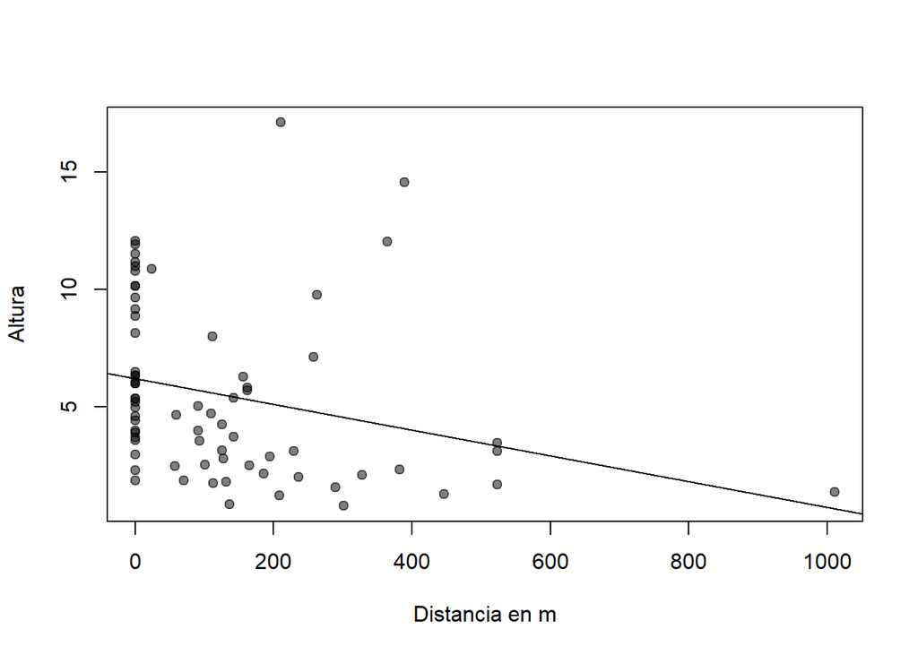

```r
plot(cwmPar$Caprino, cwmPar$Altura, pch = 19, col = rgb(0,0,0,0.5),
     xlab="Distancia en m", ylab="Altura")
abline(mod)
```

### 2.1.1 Ejercicio 1

Explora las otras variables cuantitativas que se encuentran en la matriz de traits y relacionarlos con las dos variables de disturbio, distancia y fecas.

## 2.2 Variables Cualitativas

Aunque el CWM es una medida que nos brinda interesante información sobre los rasgos dominantes dentro de la comunidad, esta medida no puede ser usada con variables cualitativas. En este caso es necesario tener una aproximación diferente, podemos usar una aproximación de análisis multivariante. Lo que haremos es obtener la frecuencia de cada nivel de la variable categórica y hacer una ordenación con estos datos.

```r
##Unimos los datos de vegetación con los traits
##categóricos

vgT <- merge(vegeT, trait[, c(1,7,8)], by.x = "Especies",
             by.y = "especies")

crec <- aggregate(vgT[,2:73], by=list(crec=vgT$Crecimiento),
                  sum)
crecT <- t(crec[,-1])
colnames(crecT) <- crec[,1]

fen <- aggregate(vgT[,2:73], by=list(fen=vgT$Fenolog.a.hoja),
                  sum)
fenT <- t(fen[,-1])
colnames(fenT) <- fen[,1]

##Hacemos una ordenación
##Verificamos la respuesta
library(vegan)
ordCrec <- decorana(crecT)
ordCrec
```

```
##
## Call:
## decorana(veg = crecT)
##
## Detrended correspondence analysis with 26 segments.
## Rescaling of axes with 4 iterations.
##
##                   DCA1    DCA2    DCA3     DCA4
## Eigenvalues     0.1450 0.10170 0.08309 0.061838
## Decorana values 0.1456 0.04799 0.01935 0.009689
## Axis lengths    1.0219 1.15952 1.05735 0.744298
```

```r
ordFen <- decorana(fenT)
ordFen
```

```
##
## Call:
## decorana(veg = fenT)
##
## Detrended correspondence analysis with 26 segments.
## Rescaling of axes with 4 iterations.
##
##                   DCA1   DCA2    DCA3    DCA4
## Eigenvalues     0.2851 0.1914 0.19134 0.19139
## Decorana values 0.2851 0.1461 0.02625 0.02014
## Axis lengths    1.4751 1.8017 1.80161 1.80188
```

```r
##Hacemos un pca

pcaCrec <- rda(crecT)
summary(pcaCrec)
```

```
##
## Call:
## rda(X = crecT)
##
## Partitioning of variance:
##               Inertia Proportion
## Total           589.8          1
## Unconstrained   589.8          1
##
## Eigenvalues, and their contribution to the variance
##
## Importance of components:
##                            PC1      PC2      PC3
## Eigenvalue            574.5944 13.94052 1.215702
## Proportion Explained    0.9743  0.02364 0.002061
## Cumulative Proportion   0.9743  0.99794 1.000000
##
## Scaling 2 for species and site scores
## * Species are scaled proportional to eigenvalues
## * Sites are unscaled: weighted dispersion equal on all dimensions
## * General scaling constant of scores:  14.3048
##
##
## Species scores
##
##               PC1       PC2        PC3
## arbol    14.10130 -0.111996 -0.0032014
## arbolito -0.07013 -0.001344 -0.6494648
## arbusto   0.71897  2.196459 -0.0005607
##
##
## Site scores (weighted sums of species scores)
##
##             PC1      PC2      PC3
## C1.P1  -1.96874 -0.27206  1.51764
## C1.P2  -0.97491 -0.14212  1.41006
## C1.P3  -1.61148  0.06627  1.47836
## C10.P1 -1.80599  2.40594 -0.04521
## C10.P2 -0.75947  0.24224 -0.15373
## C10.P3 -1.68687 -0.36551 -3.13179
```

[output cut: 51 more lines]

```
## C5.P1   0.36896 -0.58205  1.26586
## C5.P2   0.86336 -0.74468 -1.86665
## C5.P3  -0.34230 -0.80488 -0.19661
## C6.P1  -0.69560 -0.68884  1.38103
## C6.P2  -0.62487 -0.71199  1.37344
## C6.P3  -0.41268 -0.78145  1.35067
## C7.P1  -1.32566  0.42719 -1.63270
## C7.P2  -1.47037  0.01968 -0.07651
## C7.P3  -1.18780 -0.07322 -1.64655
## C8.P1  -0.61475  0.64975 -1.70993
## C8.P2  -0.12255  0.03413  1.31765
## C8.P3   2.28192 -0.75339 -0.48008
## C9.P1  -0.41338 -0.78201 -1.72871
## C9.P2  -0.76703 -0.66624 -1.69076
## C9.P3  -1.61183  0.06599 -0.06133
```

```r
pcaFen <- rda(fenT)
summary(pcaFen)
```

```
##
## Call:
## rda(X = fenT)
##
## Partitioning of variance:
##               Inertia Proportion
## Total           640.6          1
## Unconstrained   640.6          1
##
## Eigenvalues, and their contribution to the variance
##
## Importance of components:
##                            PC1      PC2      PC3
## Eigenvalue            565.8149 41.71237 33.07897
## Proportion Explained    0.8832  0.06511  0.05164
## Cumulative Proportion   0.8832  0.94836  1.00000
##
## Scaling 2 for species and site scores
## * Species are scaled proportional to eigenvalues
## * Sites are unscaled: weighted dispersion equal on all dimensions
## * General scaling constant of scores:  14.60368
##
##
## Species scores
##
##                    PC1      PC2     PC3
## defolia        13.7102 -0.08094  0.1346
## semi.defoliada -0.4773 -3.47917  1.1832
## siempre.verde   0.4133 -1.33248 -3.0975
##
##
## Site scores (weighted sums of species scores)
##
##             PC1      PC2        PC3
## C1.P1  -1.52815  1.98871  0.0077702
## C1.P2  -0.44584  1.59211  0.9684738
## C1.P3  -1.37380  1.59324 -1.0928770
## C10.P1 -1.25913  0.40352  1.3712626
## C10.P2 -0.30787  0.82883  1.3152291
## C10.P3 -1.24461  1.21377  0.3789633
```

[output cut: 51 more lines]

```
## C5.P1  -1.08706 -4.81667  2.9941611
## C5.P2  -0.15878 -2.58914 -1.0686349
## C5.P3  -0.16264  0.47068  1.1658348
## C6.P1  -1.19716 -1.29746  1.4655743
## C6.P2  -1.35979 -2.34659  2.5408751
## C6.P3  -1.32011 -1.55235 -1.0239116
## C7.P1  -1.48104 -0.86901  0.9205493
## C7.P2  -1.70158 -0.75557  1.1651640
## C7.P3  -1.45048 -0.03745 -1.6929846
## C8.P1  -0.14846  0.93443 -0.0002965
## C8.P2   0.65099  2.00575  0.9368780
## C8.P3   2.40776  0.34661 -0.6977219
## C9.P1  -1.62645 -3.03227 -0.4281516
## C9.P2  -1.55737 -2.15321  0.4942736
## C9.P3  -1.45165  1.09799 -0.8902174
```

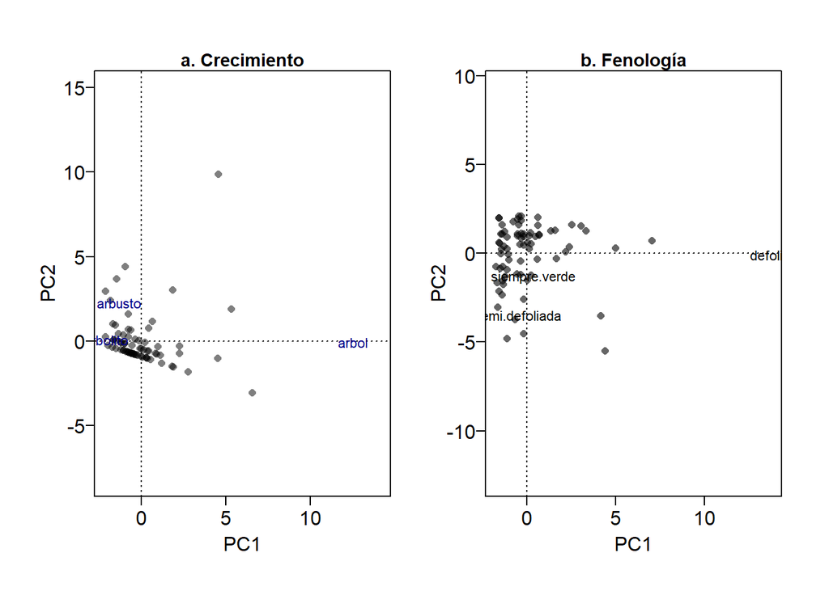

```r
par(mfcol=c(1,2), mar=c(3,3,1,1), oma=c(1,1,2,1), mgp=c(1.5,0.4,0), tck=-0.03)
plot(pcaCrec, scaling=2, type="n", las=1)
points(pcaCrec, display = "sites", col=rgb(0,0,0,0.5), pch=16, cex=0.8)
text(pcaCrec, display = "spec",cex=0.7,pos=2, col="darkblue")
mtext("a. Crecimiento", side=3, cex=0.9, font=2)

plot(pcaFen, scaling=2, type="n", las=1)
points(pcaFen, display = "sites", col=rgb(0,0,0,0.6), pch=16, cex=0.8)
text(pcaFen, display = "spec",cex=0.7)
mtext("b. Fenología", side=3, cex=0.9, font=2)
```

```r
traitC <- data.frame(COD.PAR=names(summary(pcaFen)$sites[,1]),
                     fen=summary(pcaFen)$sites[,1],
                     crec=summary(pcaCrec)$sites[,1])

##Juntamos con los datos de parcelas
traitCP <- merge(traitC, parF, by="COD.PAR")

#Ajustamos los modelos

modCD <- lm(crec~DISTANCIA, data=traitCP)
summary(modCD)
```

```
##
## Call:
## lm(formula = crec ~ DISTANCIA, data = traitCP)
##
## Residuals:
##     Min      1Q  Median      3Q     Max
## -2.0760 -1.0598 -0.4299  0.4682  6.4547
##
## Coefficients:
##               Estimate Std. Error t value Pr(>|t|)
## (Intercept) -0.1702645  0.3274066  -0.520    0.605
## DISTANCIA    0.0001455  0.0002210   0.659    0.512
##
## Residual standard error: 1.704 on 70 degrees of freedom
## Multiple R-squared:  0.006157,   Adjusted R-squared:  -0.00804
## F-statistic: 0.4337 on 1 and 70 DF,  p-value: 0.5123
```

```r
modCC <- lm(crec~Caprino, data=traitCP)
summary(modCC)
```

```
##
## Call:
## lm(formula = crec ~ Caprino, data = traitCP)
##
## Residuals:
##     Min      1Q  Median      3Q     Max
## -2.1012 -0.9833 -0.4379  0.3442  6.8383
##
## Coefficients:
##               Estimate Std. Error t value Pr(>|t|)
## (Intercept)  0.1248037  0.2487635   0.502    0.617
## Caprino     -0.0009602  0.0011333  -0.847    0.400
##
## Residual standard error: 1.701 on 70 degrees of freedom
## Multiple R-squared:  0.01015,    Adjusted R-squared:  -0.003988
## F-statistic: 0.718 on 1 and 70 DF,  p-value: 0.3997
```

```r
modFD <- lm(fen~DISTANCIA, data=traitCP)
summary(modFD)
```

```
##
## Call:
## lm(formula = fen ~ DISTANCIA, data = traitCP)
##
## Residuals:
##     Min      1Q  Median      3Q     Max
## -1.7997 -1.3322 -0.3981  0.4995  6.8703
##
## Coefficients:
##               Estimate Std. Error t value Pr(>|t|)
## (Intercept) -0.2364402  0.3333659  -0.709    0.481
## DISTANCIA    0.0002021  0.0002250   0.898    0.372
##
## Residual standard error: 1.736 on 70 degrees of freedom
## Multiple R-squared:  0.01139,    Adjusted R-squared:  -0.00273
## F-statistic: 0.8067 on 1 and 70 DF,  p-value: 0.3722
```

```r
modFC <- lm(fen~Caprino, data=traitCP)
summary(modFC)
```

```
##
## Call:
## lm(formula = fen ~ Caprino, data = traitCP)
##
## Residuals:
##     Min      1Q  Median      3Q     Max
## -1.7445 -1.1928 -0.4456  0.2911  7.2635
##
## Coefficients:
##               Estimate Std. Error t value Pr(>|t|)
## (Intercept)  0.1033774  0.2544058   0.406    0.686
## Caprino     -0.0007954  0.0011590  -0.686    0.495
##
## Residual standard error: 1.74 on 70 degrees of freedom
## Multiple R-squared:  0.006683,   Adjusted R-squared:  -0.007507
## F-statistic: 0.471 on 1 and 70 DF,  p-value: 0.4948
```